# Delhi temperature timeseries data SARIMA model fitting

Here we are doing a time-series analysis of the daily temperature in the city of Delhi for the period of Jan 01, 1995 to Dec 31, 2019.

**Reading the data**

```r
DelhiTemp <- read.csv(file = '../../../Data/Delhi_temperature_1995_2020.csv')
```

**Viewing the data**

```r
head(DelhiTemp)
```

```
##   Month Day Year Temperature
## 1     1   1 1995        50.7
## 2     1   2 1995        52.1
## 3     1   3 1995        53.8
## 4     1   4 1995        53.7
## 5     1   5 1995        54.5
## 6     1   6 1995        54.3
```

Creating a date column from Month, Day and Year columns.

```r
DelhiTemp$Date <- as.Date(with(DelhiTemp, paste(Year, Month, Day,sep="-")), "%Y-%m-%d")
```

Temperature vs. Date plot

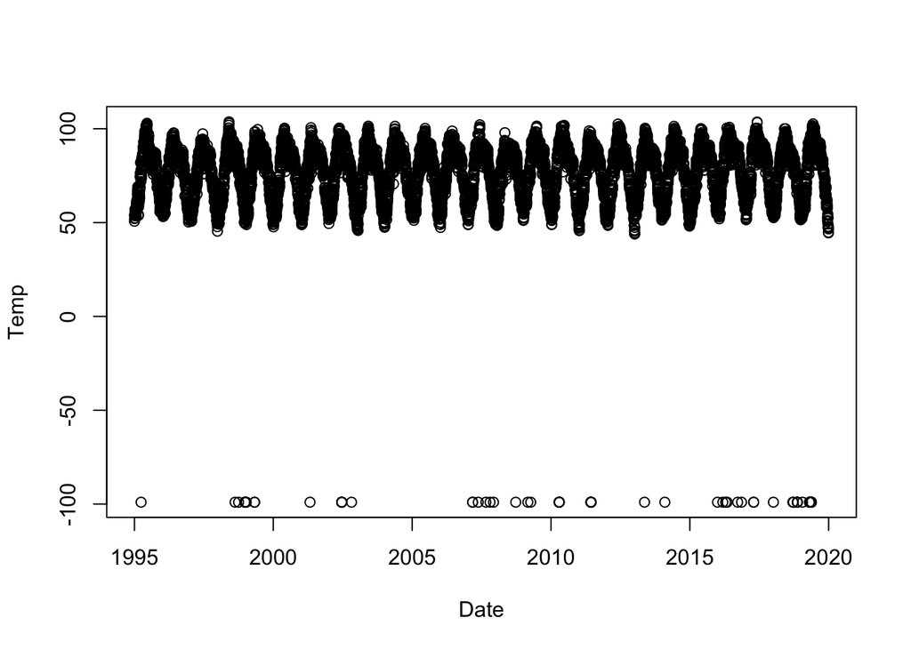

```r
Temp <- DelhiTemp$Temperature
Date <- DelhiTemp$Date
plot(Temp~Date)
```

Our data shows clear yearly seasonality and their are some very large outliers (temperature~-100) possibly because of missing data for those dates.

### Outlier detection and missing value treatment

Identifying outliers and replacing them with backfilled values:

```r
DelhiTemp$Temperature[DelhiTemp$Temperature < 0] <- NA
which(is.na(DelhiTemp$Temperature))
```

```
##  [1]   88 1324 1370 1454 1455 1460 1461 1471 1580 1581 2310 2726 2727 2728 2729
## [16] 2856 4448 4449 4523 4623 4678 4724 5016 5175 5213 5586 5587 5588 5590 6004
## [31] 6005 6006 6007 6008 6710 6977 7670 7740 7777 7796 7935 7986 8145 8146 8405
## [46] 8661 8668 8719 8720 8722 8789 8880 8881 8883 8886 8902 8903 8904 8905
```

```r
DelhiTemp$Temperature <- na.locf(DelhiTemp$Temperature, fromLast = TRUE)
which(is.na(DelhiTemp$Temperature))
```

```
## integer(0)
```

**Updated Temperature vs. Date plot**

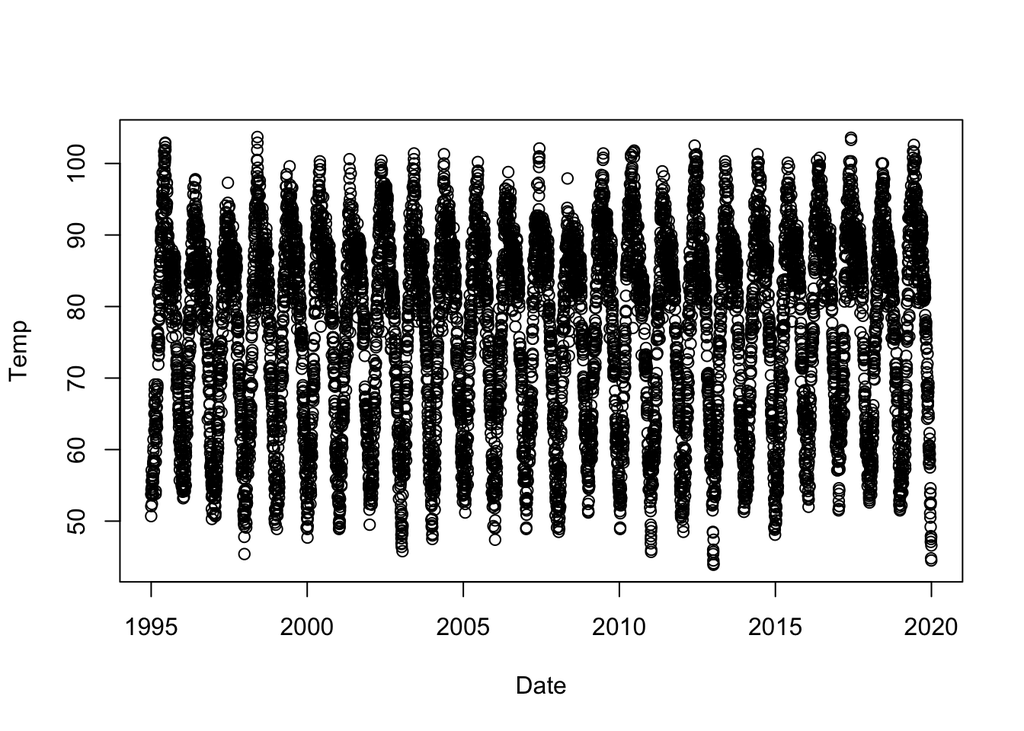

```r
Temp <- DelhiTemp$Temperature
Date <- DelhiTemp$Date
plot(Temp~Date)
```

### Binning

Binning temperatures to their mean monthly values

```r
DelhiMonthlyTemp <- DelhiTemp %>% group_by(Year,Month) %>% summarize(Temperature = mean(Temperature))
head(DelhiMonthlyTemp);
```

```
## # A tibble: 6 x 3
## # Groups:   Year [1]
##    Year Month Temperature
##   <int> <int>       <dbl>
## 1  1995     1        55.5
## 2  1995     2        62.4
## 3  1995     3        70.5
## 4  1995     4        83.1
## 5  1995     5        93.2
## 6  1995     6        95.8
```

Setting a new date column with just the month and year info

```r
DelhiMonthlyTemp$Date <- as.yearmon(paste(DelhiMonthlyTemp$Year, DelhiMonthlyTemp$Month), "%Y %m")
```

**Monthly mean temperature vs. Date (Month) plot**

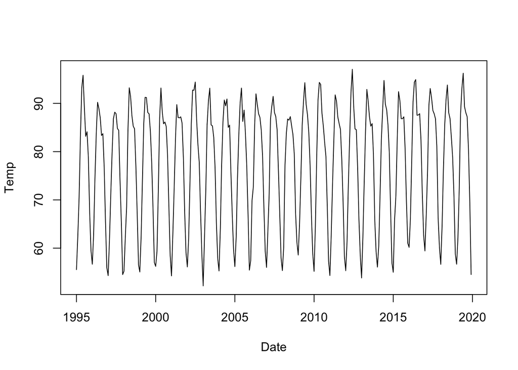

```r
Temp <- DelhiMonthlyTemp$Temperature
Date <- DelhiMonthlyTemp$Date
plot(Temp~Date,type="l")
```

Once again we see that the data shows clear seasonality but no variation in variance so differencing should be enough for taking care of the trend.

### ACF and PACF plots

Let’s first look at the auto-correlation function and the partial auto-correlation function plots.

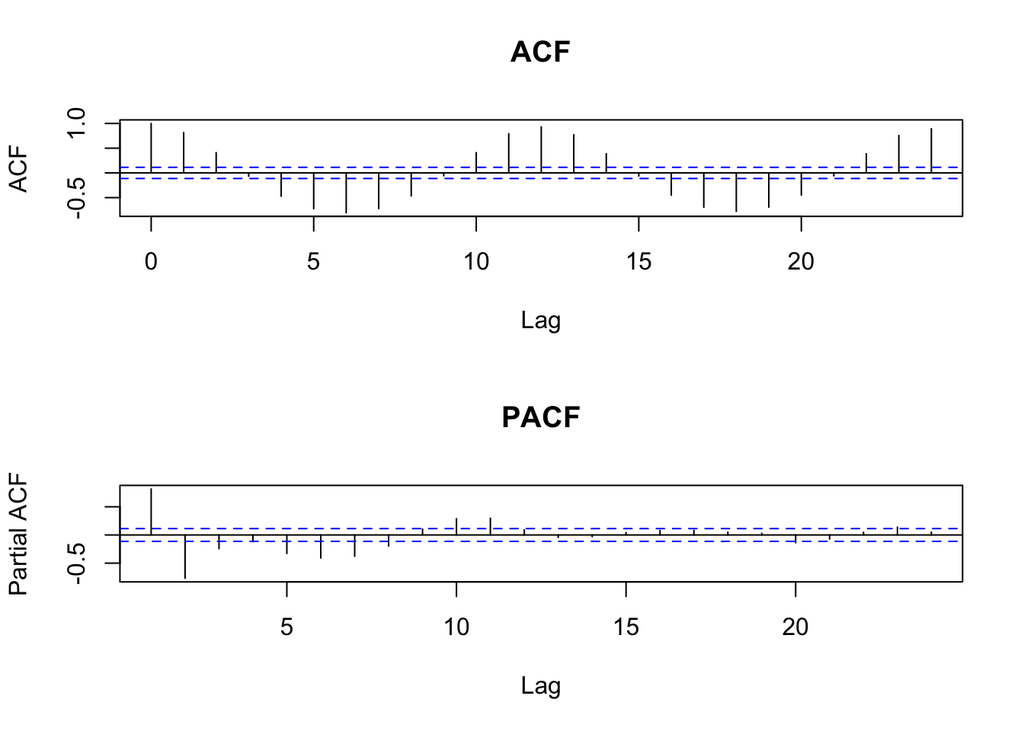

```r
Temp <- DelhiMonthlyTemp$Temperature

par(mfrow=c(2,1))
acf(Temp,main='ACF')
pacf(Temp,main='PACF');
```

We see that the ACF also shows clear seasonality.

## Guessing the right orders for (S)ARIMA model fitting

1. Differncing orders (d, D)

Non-seasonal and seasonal differencing -> *diff(diff(data),12)*

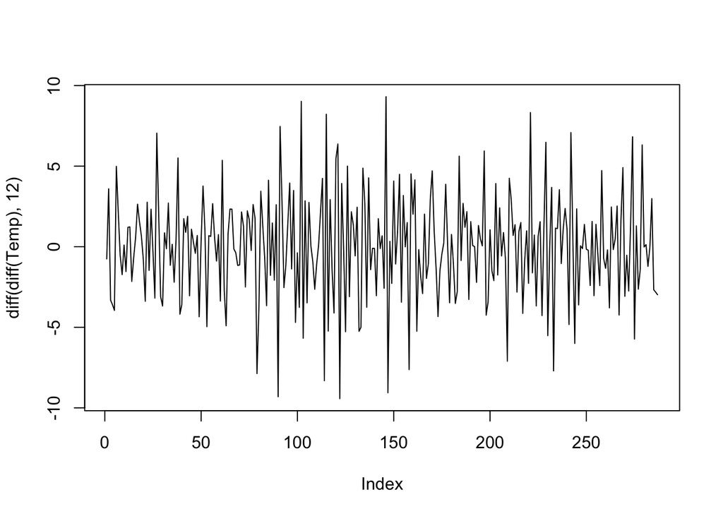

```r
plot(diff(diff(Temp),12),type="l")
```

the plot shows almost no-trends except for a few large peaks at the center which may be outliers => d=1, D=1. We can also use the AD Fuller test for checking the stationarity

```r
#diff_data <- diff(diff(Temp),12)
#adf.test(diff_data)
```

2. orders for the auro-regressive (AR) and Moving Average (MA) terms i.e. p and q

**ACF and PACF for differenced data**

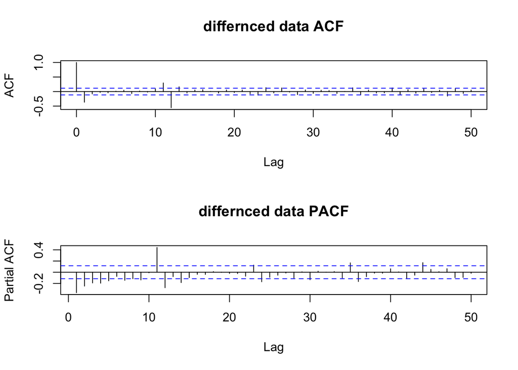

```r
par(mfrow=c(2,1))
acf(diff(diff(Temp),12),main='differnced data ACF',50)
pacf(diff(diff(Temp),12),main='differnced data PACF',50);
```

### Finding best parameters using

1. Grid Search

Trying for different values of p,q,P,Q and note down AIC, SSE and p-value (for Ljun-box-test). We want high p-values and small AIC and SSE using parsimony principle (simpler the better) while searching

```r
d=1; DD=1; per=12

for(p in 1:2){
  for(q in 1:2){
    for(i in 1:6){
      for(j in 1:3){
        if(p+d+q+i+DD+j<=10){

          model<-arima(x=Temp, order = c((p-1),d,(q-1)), seasonal = list(order=c((i-1),DD,(j-1)), period=per))

          pval<-Box.test(model$residuals, lag=log(length(model$residuals)))

          sse<-sum(model$residuals^2)

          cat(p-1,d,q-1,i-1,DD,j-1,per, 'AIC=', model$aic, ' SSE=',sse,' p-VALUE=', pval$p.value,'\n')

        }
      }
    }
  }
}
```

```
## 0 1 0 0 1 0 12 AIC= 1499.338  SSE= 3099.001  p-VALUE= 8.952575e-08
## 0 1 0 0 1 1 12 AIC= 1320.604  SSE= 1476.127  p-VALUE= 8.894564e-07
## 0 1 0 0 1 2 12 AIC= 1320.109  SSE= 1502.587  p-VALUE= 1.212609e-06
## 0 1 0 1 1 0 12 AIC= 1392.531  SSE= 2087.502  p-VALUE= 1.215459e-06
## 0 1 0 1 1 1 12 AIC= 1319.835  SSE= 1500.886  p-VALUE= 1.226718e-06
## 0 1 0 1 1 2 12 AIC= 1320.854  SSE= 1488.524  p-VALUE= 1.356503e-06
## 0 1 0 2 1 0 12 AIC= 1370.082  SSE= 1901.339  p-VALUE= 7.147622e-07
## 0 1 0 2 1 1 12 AIC= 1321.25  SSE= 1485.317  p-VALUE= 1.148136e-06
## 0 1 0 2 1 2 12 AIC= 1322.845  SSE= 1486.992  p-VALUE= 1.336722e-06
## 0 1 0 3 1 0 12 AIC= 1349.824  SSE= 1740.855  p-VALUE= 4.246554e-06
## 0 1 0 3 1 1 12 AIC= 1322.842  SSE= 1494.211  p-VALUE= 1.265004e-06
## 0 1 0 4 1 0 12 AIC= 1344.303  SSE= 1686.293  p-VALUE= 3.323896e-06
## 0 1 1 0 1 0 12 AIC= 1409.009  SSE= 2237.481  p-VALUE= 0.02513918
## 0 1 1 0 1 1 12 AIC= 1238.17  SSE= 1070.666  p-VALUE= 0.01793177
## 0 1 1 0 1 2 12 AIC= 1239.052  SSE= 1060.471  p-VALUE= 0.01667548
```

[output cut: 21 more lines]

2. Using auto.arima()

```r
y <- msts(Temp, seasonal.periods=c(12))
auto.arima( y, d = 1, D = 1,  max.p = 5,  max.q = 5,  max.P = 5,  max.Q = 5, max.order = 10,  start.p = 1,  start.q = 1,  start.P = 0, start.Q = 0, stationary = FALSE, seasonal = TRUE, ic="aic", stepwise = TRUE, approximation = FALSE)
```

```
## Series: y
## ARIMA(5,1,0)(5,1,0)[12]
##
## Coefficients:
##           ar1      ar2      ar3      ar4      ar5     sar1     sar2     sar3
##       -0.5142  -0.4444  -0.3373  -0.2261  -0.1488  -0.8628  -0.6184  -0.4755
## s.e.   0.0606   0.0653   0.0695   0.0676   0.0603   0.0625   0.0823   0.0867
##          sar4     sar5
##       -0.2962  -0.1132
## s.e.   0.0850   0.0654
##
## sigma^2 estimated as 4.656:  log likelihood=-628.94
## AIC=1279.88   AICc=1280.84   BIC=1320.13
```

### Best-model

For some reason auto-arima is unable to reproduce the minimum value of AIC which was found in the grid-search method. From the grid-search the lowest AIC of 1221.998 is found for a 1,1,1,0,1,1,12 SARIMA model which also has a large enough p-value.

### SARIMA(1,1,1,0,1,1,12) fitting results

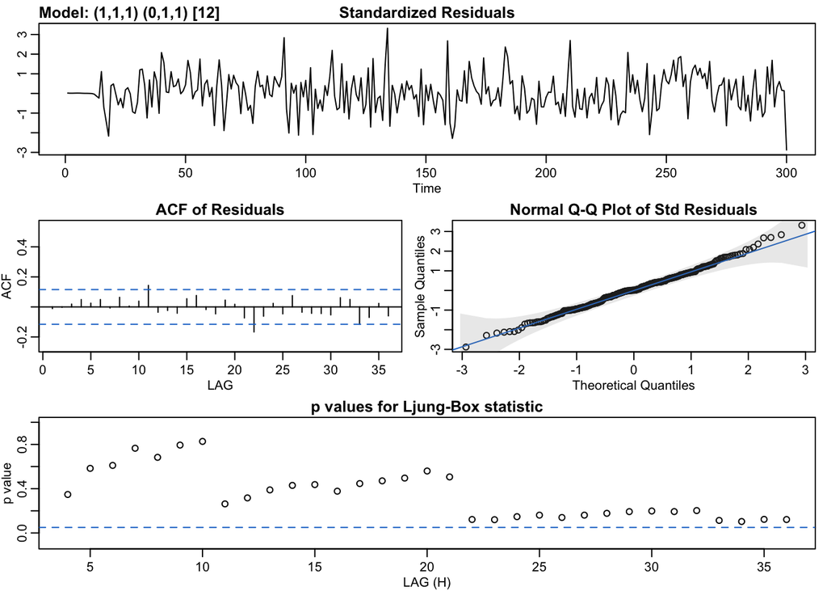

```
## $fit
##
## Call:
## stats::arima(x = xdata, order = c(p, d, q), seasonal = list(order = c(P, D,
##     Q), period = S), include.mean = !no.constant, transform.pars = trans, fixed = fixed,
##     optim.control = list(trace = trc, REPORT = 1, reltol = tol))
##
## Coefficients:
##          ar1      ma1     sma1
##       0.3468  -1.0000  -0.9999
## s.e.  0.0563   0.0386   0.0874
##
## sigma^2 estimated as 3.409:  log likelihood = -607,  aic = 1222
##
## $degrees_of_freedom
## [1] 284
##
## $ttable
##      Estimate     SE  t.value p.value
## ar1    0.3468 0.0563   6.1606       0
## ma1   -1.0000 0.0386 -25.8977       0
## sma1  -0.9999 0.0874 -11.4404       0
##
## $AIC
## [1] 4.100663
##
## $AICc
## [1] 4.100937
##
## $BIC
## [1] 4.149784
```

```r
sarima(Temp,1,1,1,0,1,1,12);
```

### Forecasting using the best-model

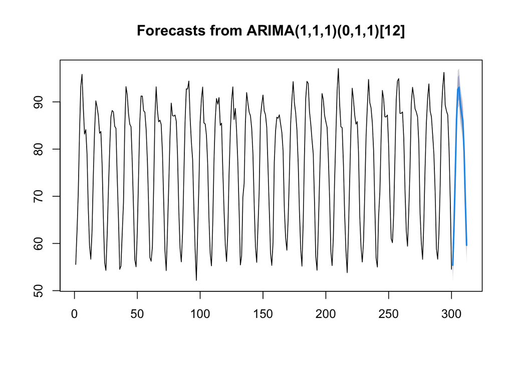

```r
model<-arima(x=Temp, order = c(1,1,1), seasonal = list(order=c(0,1,1), period=per))
par(mfrow=c(1,1))
plot(forecast(model,12)); # forecasting for the 12 months after the end of the dataset
```